# Data 612 Project 4 - Accuracy and Beyond

Vinayak Patel

2020-07-02

```r
if (!require("knitr")) install.packages("knitr")
if (!require("tidyverse")) install.packages("tidyverse")
if (!require("kableExtra")) install.packages("kableExtra")
if (!require("dplyr")) install.packages("dplyr")
if (!require("ggrepel")) install.packages("ggrepel")
if (!require("recommenderlab")) install.packages("recommenderlab")
if (!require("tictoc")) install.packages("tictoc")
```

## Introduction

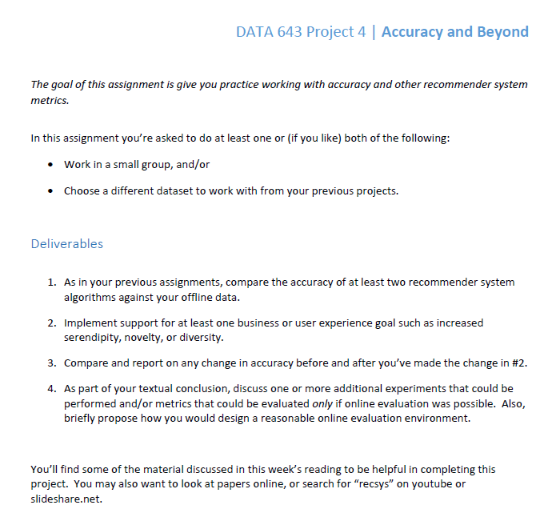

## Data

### Load your data into (for example)**

● For this case study, The dataset is a product ratings for Electronics products sold on Amazon.com.

Attribute Information:

● `userId` : Every user identified with a unique id (First Column)

● `productId` : Every product identified with a unique id(Second Column)

● `Rating` : Rating of the corresponding product by the corresponding user(Third Column)

● `timestamp` : Time of the rating ( Fourth Column)

```r
ratings_data <- read.csv('C:/Users/patel/Documents/Data612/Project4/ratings_Electronics.csv')
dim(ratings_data)
```

```
## [1] 6197180       4
```

### Display your data

```r
head(ratings_data) %>% kable()%>%
  kable_styling(bootstrap_options = "striped", full_width = F)
```

| userId | productId | Rating | timestamp |
| --- | --- | --- | --- |
| AKM1MP6P0OYPR | 0132793040 | 5 | 1365811200 |
| A2CX7LUOHB2NDG | 0321732944 | 5 | 1341100800 |
| A2NWSAGRHCP8N5 | 0439886341 | 1 | 1367193600 |
| A2WNBOD3WNDNKT | 0439886341 | 3 | 1374451200 |
| A1GI0U4ZRJA8WN | 0439886341 | 1 | 1334707200 |
| A1QGNMC6O1VW39 | 0511189877 | 5 | 1397433600 |

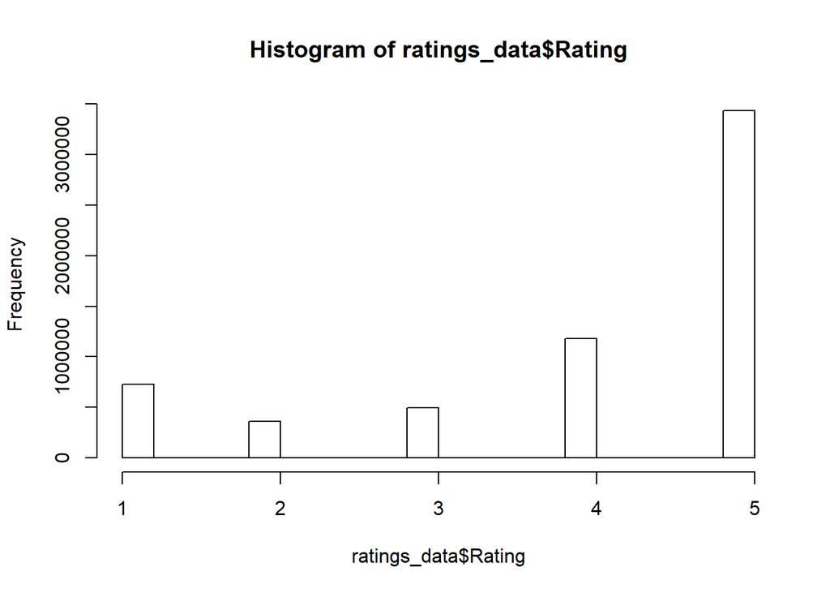

```r
hist(ratings_data$Rating)
```

### Transform Data

I used `realRatingMatrix` from ‘recommenderlab’ to transform data.

```r
class(ratings_data$userId)
```

```
## [1] "factor"
```

```r
class(ratings_data$productId)
```

```
## [1] "factor"
```

```r
class(ratings_data$Rating)
```

```
## [1] "numeric"
```

```r
class(ratings_data$timestamp)
```

```
## [1] "integer"
```

```r
ratings_data$userId <- as.factor(ratings_data$userId)

UI <- as(ratings_data, "realRatingMatrix")
dim(UI@data)
```

```
## [1] 3492876  343145
```

```r
( amazonShort <- UI[rowCounts(UI) > 20, colCounts(UI) > 40] )
```

```
## 8086 x 25197 rating matrix of class 'realRatingMatrix' with 189308 ratings.
```

```r
amazonShort <- UI[ , colCounts(UI) > 40]
amazonShort <- amazonShort[rowCounts(amazonShort) > 20, ]
amazonShort
```

```
## 3573 x 25197 rating matrix of class 'realRatingMatrix' with 118551 ratings.
```

Step-6) Check and Remove Empty Lines

```r
table(rowCounts(amazonShort))
```

```
##
##  21  22  23  24  25  26  27  28  29  30  31  32  33  34  35  36  37  38
## 401 325 282 232 224 203 172 163 143 106 105  95  86  76  47  70  46  60
##  39  40  41  42  43  44  45  46  47  48  49  50  51  52  53  54  55  56
##  41  49  44  39  25  24  31  26  28  24  16  24  26  17  18  20  14  11
##  57  58  59  60  61  62  63  64  65  66  67  68  69  70  71  72  73  74
##  11   9   8  15  10   6   6  10  13   6   7  12   2   5   8   5   5   4
##  75  76  77  78  79  80  81  82  83  84  85  86  87  88  89  91  92  93
##   4   1   3   4   7   6   3   3   4   4   3   2   1   1   1   2   1   2
##  94  95  96  97  98 100 101 103 104 105 106 107 109 110 112 113 114 117
##   4   2   2   1   1   2   2   1   2   1   2   2   1   1   1   1   2   2
## 118 119 121 122 123 125 126 127 128 129 130 131 133 138 139 140 158 159
##   1   3   1   4   4   1   1   1   1   2   1   2   1   1   1   2   1   1
## 171 181 219 244 256 263 284
##   1   1   1   1   1   1   1
```

```r
table(colCounts(amazonShort))
```

```
##
##    0    1    2    3    4    5    6    7    8    9   10   11   12   13   14
## 5706 5088 3568 2432 1712 1164  930  677  530  385  341  308  248  222  183
##   15   16   17   18   19   20   21   22   23   24   25   26   27   28   29
##  142  149  127  119   91   94   87   80   54   39   41   47   35   47   34
##   30   31   32   33   34   35   36   37   38   39   40   41   42   43   44
##   37   21   31   15   28   17   19   20   11   15   14   13   15    5    7
##   45   46   47   48   49   50   51   52   53   54   55   56   57   58   59
##   10    6    9    4   12    8   11    9    8    9    7    6    6    1    3
##   60   61   62   63   64   65   66   67   68   69   71   72   73   74   75
##    5    7    4    5    2    4    5    2    6    3    3    2    2    2    1
##   76   78   79   80   81   82   83   85   87   88   89   91   92   95   96
##    3    3    3    1    5    4    1    2    2    3    1    2    2    1    1
##   98  100  102  105  107  111  113  116  118  120  121  123  129  130  132
##    2    1    1    2    1    1    4    3    1    2    1    1    1    1    1
##  134  137  142  143  145  146  149  151  152  155  156  163  165  168  169
##    2    1    2    1    1    1    1    1    1    3    1    1    1    1    2
##  176  187  195  212  214  229  239  273  342  352
##    1    1    1    1    1    1    1    1    1    1
```

```r
( amazonShort <- amazonShort[ , colCounts(amazonShort) != 0] )
```

```
## 3573 x 19491 rating matrix of class 'realRatingMatrix' with 118551 ratings.
```

# Data import and Data Preparation

Import the ratings_final dataset:

```r
ratings <- read.csv("ratings_final.csv")

class(ratings$userId)
```

```
## [1] "factor"
```

```r
class(ratings$productId)
```

```
## [1] "factor"
```

```r
class(ratings$Rating)
```

```
## [1] "integer"
```

```r
amazon <- as(ratings, "realRatingMatrix")
dim(amazon@data)
```

```
## [1]  3573 19491
```

# Train and Test sets

Split the dataset into test and train sets to build the model.

```r
# Train/test split
set.seed(88)
eval <- evaluationScheme(amazon, method = "split", train = 0.8, given = 5, goodRating = 3)
train <- getData(eval, "train")
known <- getData(eval, "known")
unknown <- getData(eval, "unknown")

# Set up data frame for timing
timing <- data.frame(Model=factor(), Training=double(), Predicting=double())
```

# Recommender Models

Now, Let’s build three different models

**USER BASED COLLABORATIVE FILTERING**

```r
model_method <- "UBCF"

# Training
tic()
modelUBCF <- Recommender(train, method = model_method)
t <- toc(quiet = TRUE)
train_time <- round(t$toc - t$tic, 2)

# Predicting
tic()
predUBCF <- predict(modelUBCF, newdata = known, type = "ratings")
t <- toc(quiet = TRUE)
predict_time <- round(t$toc - t$tic, 2)

timing <- rbind(timing, data.frame(Model = as.factor(model_method),
                                   Training = as.double(train_time),
                                   Predicting = as.double(predict_time)))
# Accuracy
accUBCF <- calcPredictionAccuracy(predUBCF, unknown)
#resultsUBCF <- evaluate(x = eval, method = model_method, n = c(1, 5, 10, 30, 60))
```

**RANDOM**

```r
model_method <- "RANDOM"

# Training
tic()
modelRandom <- Recommender(train, method = model_method)
t <- toc(quiet = TRUE)
train_time <- round(t$toc - t$tic, 2)

# Predicting
tic()
predRandom <- predict(modelRandom, newdata = known, type = "ratings")
t <- toc(quiet = TRUE)
predict_time <- round(t$toc - t$tic, 2)

timing <- rbind(timing, data.frame(Model = as.factor(model_method),
                                   Training = as.double(train_time),
                                   Predicting = as.double(predict_time)))

# Accuracy
accRandom <- calcPredictionAccuracy(predRandom, unknown)
#resultsRandom <- evaluate(x = eval, method = model_method, n = c(1, 5, 10, 30, 60))
```

**SVD**

```r
model_method <- "SVD"

# Training
tic()
modelSVD <- Recommender(train, method = model_method, parameter = list(k = 50))
t <- toc(quiet = TRUE)
train_time <- round(t$toc - t$tic, 2)

# Predicting
tic()
predSVD <- predict(modelSVD, newdata = known, type = "ratings")
t <- toc(quiet = TRUE)
predict_time <- round(t$toc - t$tic, 2)

timing <- rbind(timing, data.frame(Model = as.factor(model_method),
                                   Training = as.double(train_time),
                                   Predicting = as.double(predict_time)))

# Accuracy
accSVD <- calcPredictionAccuracy(predSVD, unknown)
#resultsSVD <- evaluate(x = eval, method = model_method, n = c(1, 5, 10, 30, 60))
```

# Compairing Models

As we have build all three models for the dataset, now we can proceed with compairing the accuracy for all three models

```r
accuracy <- rbind(accUBCF, accRandom)
accuracy <- rbind(accuracy, accSVD)
rownames(accuracy) <- c("UBCF", "Random", "SVD")
knitr::kable(accuracy, format = "html") %>%
  kableExtra::kable_styling(bootstrap_options = c("striped", "hover"))
```

|  | RMSE | MSE | MAE |
| --- | --- | --- | --- |
| UBCF | 1.097196 | 1.203839 | 0.7901769 |
| Random | 1.353277 | 1.831358 | 0.9499848 |
| SVD | 1.092688 | 1.193967 | 0.7764771 |

As we review the accuracy scores above for UBCF, Random, SVD models, we see that Random has the lowest accuracy than UBCF and SVD. Whereas, UBCF and SVD models accuracy figures are quite close to each other. It is not surprising that random recommendations are not as accurate as recommendations based on prior ratings.

# ROC curve

Now we can we can review ROC curve and Precision-Recall plot for all three models.

```r
models <- list(
  "UBCF" = list(name = "UBCF", param = NULL),
  "Random" = list(name = "RANDOM", param = NULL),
  "SVD" = list(name = "SVD", param = list(k = 50))
  )
evalResults <- evaluate(x = eval, method = models, n = c(1, 5, 10, 30, 60))
```

```
## UBCF run fold/sample [model time/prediction time]
##   1  [0.01sec/356.01sec]
## RANDOM run fold/sample [model time/prediction time]
##   1  [0sec/13.93sec]
## SVD run fold/sample [model time/prediction time]
##   1  [34.71sec/17.21sec]
```

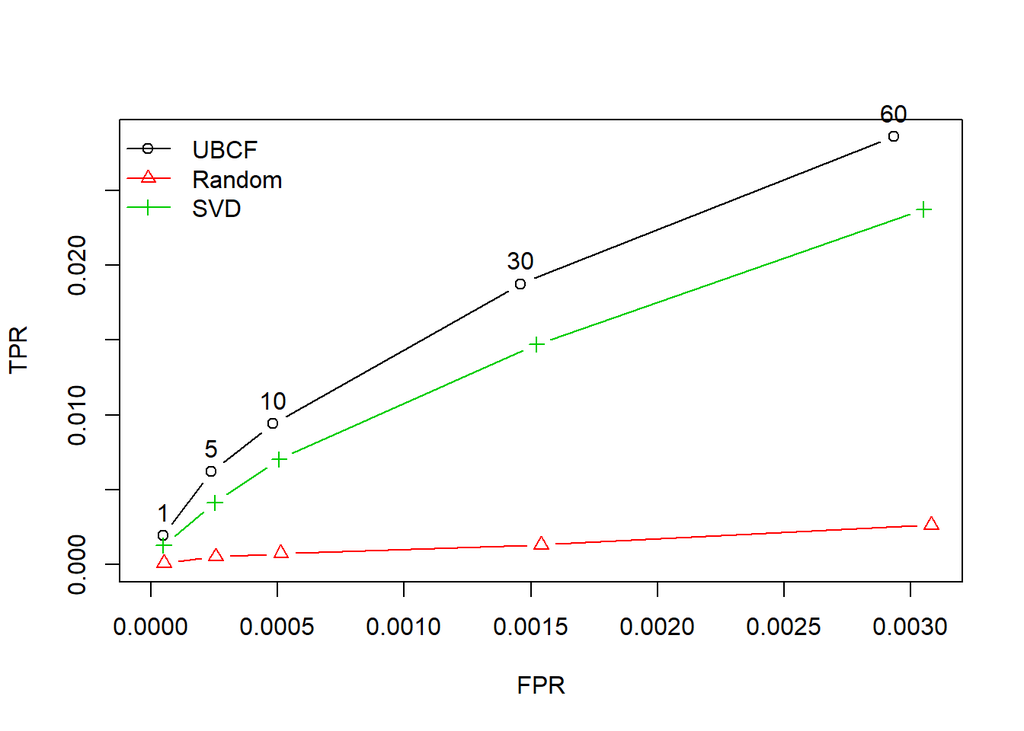

```r
# ROC Curve
plot(evalResults,
     annotate = TRUE, legend = "topleft", main = "ROC Curve")
```

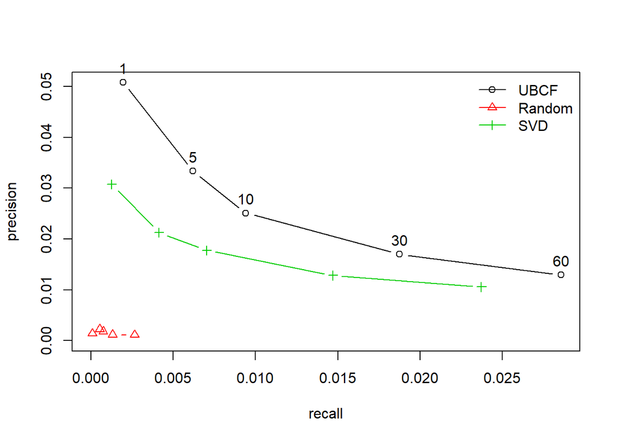

```r
# Precision-Recall Plot
plot(evalResults, "prec/rec",
     annotate = TRUE, legend = "topright", main = "Precision-Recall")
```

UBCF performs better than SVD and considerably better than the Random model.

• Now, Let us see the training and prediction time.

• From the table below we can see that the UBCF model can be created fairly quickly, but predicting results takes considerable time. The Random model is pretty efficient all around. The SVD model takes longer to build than to predict, but altogether it is quicker than the UBCF model.

```r
rownames(timing) <- timing$Model
knitr::kable(timing[, 2:3], format = "html") %>%
  kableExtra::kable_styling(bootstrap_options = c("striped", "hover"))
```

|  | Training | Predicting |
| --- | --- | --- |
| UBCF | 0.03 | 347.64 |
| RANDOM | 0.00 | 8.79 |
| SVD | 37.77 | 11.75 |

# Implement Support for Business/User Experiance Goal

• It may not always be desirable to recommend products that are likely to be most highly rated by a user. Recommending somewhat unexpected products may improve user experience, expand user preferences, provide additional knowledge about a user.

• In order to make sure that most of recommendations are still likely to be highly rated we only allow very minor influence of the Random model (0.99 vs. 0.01 weight between UBCF and Random models).

```r
model_Hybrid <- HybridRecommender(
    modelUBCF,
    modelRandom,
    weights = c(0.99, 0.01))
pred_Hybrid <- predict(model_Hybrid, newdata = known, type = "ratings")
( accHybrid <- calcPredictionAccuracy(pred_Hybrid, unknown) )
```

```
##      RMSE       MSE       MAE
## 1.4057040 1.9760037 0.9335008
```

**Comprison of the accuracy**

Let us look at top 10 recommendations for the first user in the test set.

```r
pUBCF <- predict(modelUBCF, newdata = known[1], type = "topNList")
pHybrid <- predict(model_Hybrid, newdata = known[1], type = "topNList")
```

```r
pUBCF@items
```

```
## $A107CTGSINY3GJ
##  [1]  3967 12353 12743 13029 15549 10903 13212 14521     1     2
```

```r
pHybrid@items
```

```
## $A107CTGSINY3GJ
##  [1]  3967 13029 12353 15549 12743 10903 13212 14521     1     2
```

# Conclusion

• In this project we have build three different recommender system algorithms and compared the accuracy of all the three different models. Similar process can be employed to compare additional models or to adjust model parameters to find the most optimal model.

**Additional experiments that could be performed**

• One of the approaches in measuring success of diversification may be **A/B testing.** Users are randomly divided into two groups and each group is offered a slightly different experience. For instance, one group may get recommendations only from the UBCF model while the other group will get recommendations from the hybrid model.

• User experience is measured in some way. The least instrusive way is to monitor user interaction. In this example of Amazon products, a click on a recommendation suggested by the random element of the model will point to the fact that the hybrid model provides valuable recommendations.

• Of course, it is possible to track other metrics - products bought, time spent on product page, amount spent, etc. The basic idea is to see if the hybrid model provides meaningful improvement to the basic model.

• It is important to have objective measures when building and optimizing data science models. Evaluation of a model that returns highly relevant, but redundant recommendations should reflect that the model may score poorly in user experience.

• One of the approaches to measure diversity is described in [Novelty and Diversity in Information Retrieval Evaluation](https://plg.uwaterloo.ca/~gvcormac/novelty.pdf). This or similar measurement should be incorporated in projects of this type.